# Estudo de Caso 02:Avaliação e comparação do retorno médio de ações

EEE933 - Planejamento e Análise de Experimentos

Yasmim Machado — Verificadora: compilação independente do relatório, revisão dos resultados, redação do relatório e das sugestões de melhoria

04 de outubro de 2026

# Resumo

Um investidor deseja aplicar todo o seu capital em uma única ação durante o próximo mês e dispõe dos preços de fechamento de cinco ações nos últimos 36 meses. Os preços foram convertidos em 35 retornos mensais por ação e comparados por meio de uma sequência de testes de hipóteses: ANOVA (teste global), teste de Tukey (todos contra todos), teste de Dunnett (todos contra a ação de maior média) e, por fim, um teste t para decidir entre as duas ações que restaram. O teste global rejeitou a igualdade das médias ($\alpha = 0{,}05$). As ações V2 e V4 foram descartadas pelo teste de Tukey, e V5 foi descartada pelo teste de Dunnett. Restaram V1 e V3, e a diferença entre elas é apenas marginalmente significativa, com evidência dependente do teste utilizado. A ação **V1** tem o maior retorno médio, o maior retorno por unidade de risco e foi a recomendada, com a ressalva de que o experimento tem potência limitada para separá-la de V3.

# Introdução

Um investidor deseja aplicar todo o seu capital em **uma única ação** no próximo mês, buscando o maior retorno mensal. Foram coletados os preços de fechamento de cinco ações nos últimos 36 meses. O objetivo deste relatório é:

1. determinar qual ação tem maior potencial de retorno mensal médio;
2. caso mais de uma ação se destaque, apresentar evidências adicionais para escolher uma única ação.

# Planejamento do Experimento

## Objetivos do Experimento (Hipóteses a serem testadas)

Seja $\mu_j$ o retorno mensal médio da ação $j$ ($j = 1, \dots, 5$). Os testes formam uma sequência, em que cada etapa é motivada pelo resultado da anterior.

1. **Teste global (ANOVA):** o modelo é
   $$\begin{cases}
   H_0: \tau_j = 0, \;\; \forall\, j \in \{1, 2, \ldots, 5\} \\
   H_1: \exists\, j \;:\; \tau_j \neq 0
   \end{cases}.$$
   As hipóteses são $H_0: \mu_1 = \dots = \mu_5$ (todos os efeitos $\tau_j$ são nulos) contra $H_1$: ao menos uma média difere. Se $H_0$ for rejeitada, existe ao menos uma ação cujo retorno médio é diferente das demais, mas o teste não indica qual.
2. **Teste de Tukey:** teste post-hoc que, para cada par de ações $(j, l)$, testa $H_0: \mu_j = \mu_l$ contra $H_1: \mu_j \neq \mu_l$. Serve para descartar as ações claramente inferiores.
3. **Teste de Dunnett:** compara uma ação de referência (a de maior média) com todas as demais. Como são apenas $k-1$ comparações, e não todos os pares, o teste é mais sensível que o de Tukey para esse fim, e permite descartar ações que o Tukey não separou da referência.
4. **Teste t de Student (Welch):** se restarem apenas duas ações sem diferença clara, compara-se diretamente $H_0: \mu_1 = \mu_3$ contra $H_1: \mu_1 \neq \mu_3$. Por ser uma única comparação, o teste tem maior potência do que as comparações múltiplas, que pagam o preço da correção.

O nível de significância adotado em todos os testes é $\alpha = 0.05$.

## Descrição da coleta e consolidação dos dados (Pré-processamento)

O arquivo `DadosAcoesGrupoE.csv` não possui cabeçalho. Tem 36 linhas (meses) e 5 colunas (ações, nomeadas V1 a V5 pelo R). A linha 1 é o mês mais recente e a linha 36 é o mais distante.

Adota-se a notação do enunciado: $P_{i,j}$ é o conteúdo da posição $(i, j)$ do arquivo, isto é, o preço de fechamento da ação $j$ ($j = 1, \dots, 5$) no período $i$ ($i = 1, \dots, 36$). Assim, $i$ indexa os meses (linhas) e $j$ indexa as ações (colunas), e a mesma convenção vale para os retornos $r_{i,j}$ e para o modelo da ANOVA, em que $\tau_j$ é o efeito da ação $j$.

O pré-processamento segue as simplificações do enunciado. A primeira é que o preço de abertura de um mês é idêntico ao preço de fechamento do mês anterior. Com isso, o retorno mensal pode ser calculado apenas com os preços de fechamento, e o retorno da ação $j$ no período $i$ é

$$r_{i,j} = \frac{P_{i,j} -
P_{i+1,j}}{P_{i+1,j}}$$
em que $P_{i+1,j}$ é o fechamento do mês imediatamente anterior ao mês $i$ (a linha seguinte, pois a ordenação é do mais recente para o mais antigo). A segunda simplificação é que as ações podem ser compradas de forma fracionária, de modo que todo o capital é aplicado na ação escolhida. Por isso, o ganho do investidor é proporcional ao retorno relativo $r_{i,j}$, independentemente do preço unitário de cada ação, e as ações podem ser comparadas diretamente pelos seus retornos. A linha mais antiga não possui mês anterior, portanto obtêm-se $n = 35$ retornos por ação, totalizando 175 observações.

```r
calcular_retorno <- function(preco) {
  n <- length(preco)
  # linha i é mais recente que i+1: retorno = P_i / P_{i+1} - 1
  preco[1:(n - 1)] / preco[2:n] - 1
}

acoes <- read.csv("DadosAcoesGrupoE.csv", header = FALSE)
stopifnot(nrow(acoes) == 36, ncol(acoes) == 5, !anyNA(acoes))

retornos <- as.data.frame(sapply(acoes, calcular_retorno))   # 35 x 5
n <- nrow(retornos)
k <- ncol(retornos)

# formato longo (uma linha por observação)
retornos_long <- stack(retornos)
names(retornos_long) <- c("retorno", "acao")
```

# Análise Exploratória dos Dados

O boxplot mostra a distribuição dos retornos de cada ação.

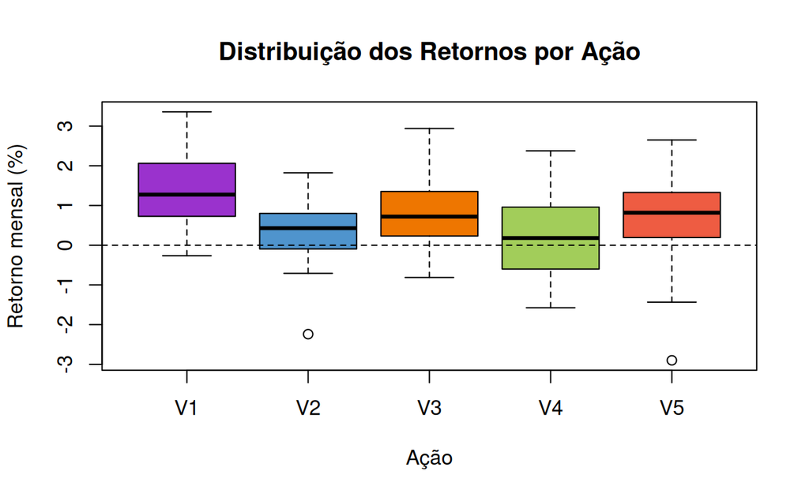

Distribuição dos retornos mensais por ação (em %).

```r
boxplot(retornos * 100,
        main = "Distribuição dos Retornos por Ação",
        xlab = "Ação", ylab = "Retorno mensal (%)",
        col = c("darkorchid3", "steelblue3", "darkorange2",
                "darkolivegreen3", "tomato2"))
abline(h = 0, lty = 2)
```

```r
desc <- data.frame(
  Media   = sapply(retornos, mean),
  DP      = sapply(retornos, sd),
  Mediana = sapply(retornos, median),
  Minimo  = sapply(retornos, min),
  Maximo  = sapply(retornos, max)
)
knitr::kable(round(desc * 100, 3),
             caption = "Estatísticas descritivas dos retornos mensais (em %).")
```

Estatísticas descritivas dos retornos mensais (em %).

|  | Media | DP | Mediana | Minimo | Maximo |
| --- | --- | --- | --- | --- | --- |
| V1 | 1.340 | 0.927 | 1.275 | -0.266 | 3.359 |
| V2 | 0.434 | 0.864 | 0.429 | -2.240 | 1.823 |
| V3 | 0.835 | 0.968 | 0.721 | -0.812 | 2.940 |
| V4 | 0.247 | 1.179 | 0.181 | -1.574 | 2.376 |
| V5 | 0.709 | 1.058 | 0.819 | -2.899 | 2.650 |

A tabela apresenta as estatísticas descritivas dos retornos mensais de cada ação, Todos os valores estão em porcentagem. A média indica o retorno esperado ao mês, e o desvio-padrão mede a variabilidade dos retornos, ou seja, o risco. Mediana, mínimo e máximo ajudam a identificar assimetria e valores extremos.

```r
medias <- colMeans(retornos)
melhor <- names(which.max(medias))
```

Considerando apenas a média, a ação com maior retorno é a **V1** (1,340% ao mês), seguida por V3 (0,835%) e V5 (0,709%). V2 e V4 têm as menores médias (0,434% e 0,247%). V4 é também a ação de maior dispersão (desvio-padrão de 1,179%). Porém, apenas as médias amostrais não permitem concluir que as diferenças são reais, o que motiva a realização dos testes seguintes.

```r
knitr::kable(round(cor(retornos), 2),
             caption = "Correlação entre os retornos das ações (mesmos meses).")
```

Correlação entre os retornos das ações (mesmos meses).

|  | V1 | V2 | V3 | V4 | V5 |
| --- | --- | --- | --- | --- | --- |
| V1 | 1.00 | 0.13 | -0.24 | -0.21 | -0.16 |
| V2 | 0.13 | 1.00 | 0.09 | 0.01 | -0.11 |
| V3 | -0.24 | 0.09 | 1.00 | 0.08 | 0.04 |
| V4 | -0.21 | 0.01 | 0.08 | 1.00 | 0.24 |
| V5 | -0.16 | -0.11 | 0.04 | 0.24 | 1.00 |

As correlações entre os retornos das ações são todas baixas (em módulo, no máximo 0,24). Isso indica que não há um movimento comum de mercado forte entre essas ações nos mesmos meses, o que é coerente com tratar as colunas como amostras aproximadamente independentes.

# Análise Estatística

As próximas seções explicam os testes realizados e os resultados obtidos. Os testes contam uma história de como escolher uma ação ideal para investimento.

## Modelo e validação das premissas

O modelo de ANOVA:

```r
modelo <- aov(retorno ~ acao, data = retornos_long)
```

### Normalidade

```r
shapiro.test(modelo$residuals)
```

```
##
##  Shapiro-Wilk normality test
##
## data:  modelo$residuals
## W = 0.98985, p-value = 0.2469
```

```r
sw <- sapply(retornos, function(x) shapiro.test(x)$p.value)
knitr::kable(data.frame(p_valor = round(sw, 4)),
             caption = "Shapiro-Wilk por ação (H0: retornos normais).")
```

Shapiro-Wilk por ação (H0: retornos normais).

|  | p_valor |
| --- | --- |
| V1 | 0.5638 |
| V2 | 0.0878 |
| V3 | 0.4969 |
| V4 | 0.0980 |
| V5 | 0.0239 |

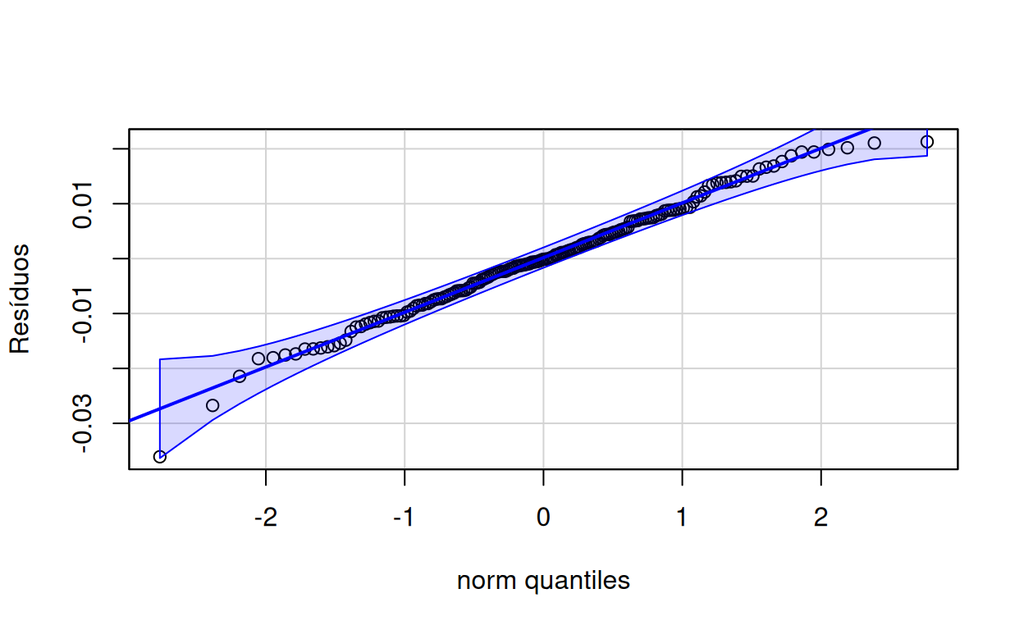

QQ-plot dos resíduos do modelo.

```r
library(car)
qqPlot(modelo$residuals, ylab = "Resíduos", id = FALSE)
```

O teste de Shapiro-Wilk sobre os resíduos do modelo tem p-valor de 0,2469, portanto não rejeita a normalidade ao nível de 5%. O QQ-plot confirma o resultado: os pontos acompanham a reta e ficam dentro da banda de confiança.

### Homoscedasticidade

```r
fligner.test(retorno ~ acao, data = retornos_long)
```

```
##
##  Fligner-Killeen test of homogeneity of variances
##
## data:  retorno by acao
## Fligner-Killeen:med chi-squared = 6.0758, df = 4, p-value = 0.1936
```

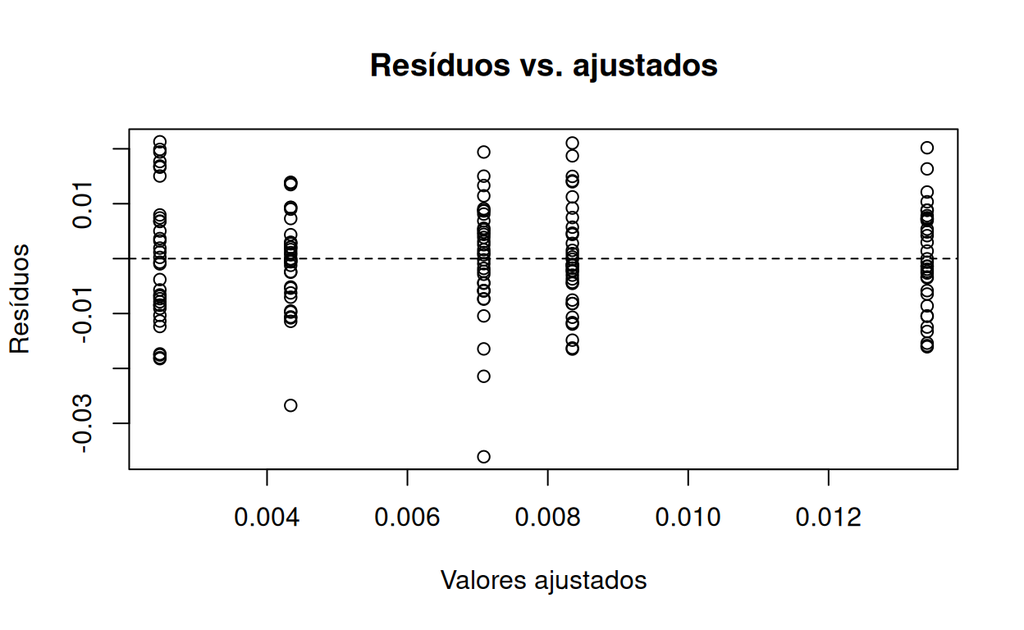

```r
plot(x = modelo$fitted.values, y = modelo$residuals,
     xlab = "Valores ajustados", ylab = "Resíduos",
     main = "Resíduos vs. ajustados")
abline(h = 0, lty = 2)
```

### Independência

Não existe um teste capaz de comprovar a independência, que deve ser garantida no planejamento do experimento. Neste estudo ela é assumida: cada retorno é a variação relativa de um único mês, e não há observações repetidas da mesma unidade. Como indício complementar, as correlações entre as ações nos mesmos meses são baixas (Tabela de correlação na Análise Exploratória), o que sugere que não há um efeito comum de mercado forte que exigiria tratar o mês como bloco.

## Teste ANOVA

O primeiro teste avalia se as médias de retorno das cinco ações são iguais. As hipóteses são:

- $H_0$: **as médias de retorno das cinco ações são iguais** ($\mu_1 = \mu_2 = \mu_3 = \mu_4 = \mu_5$, ou seja, $\tau_j = 0$ para todo $j$);
- $H_1$: **ao menos uma ação tem retorno médio diferente das demais** ($\exists\, j : \tau_j \neq 0$).

```r
summary(modelo)
```

```
##              Df   Sum Sq   Mean Sq F value   Pr(>F)
## acao          4 0.002462 0.0006155   6.092 0.000132 ***
## Residuals   170 0.017175 0.0001010
## ---
## Signif. codes:  0 '***' 0.001 '**' 0.01 '*' 0.05 '.' 0.1 ' ' 1
```

```r
p_anova <- summary(modelo)[[1]][["Pr(>F)"]][1]
p_anova
```

```
## [1] 0.0001323065
```

O p-valor de $1{,}32 \times 10^{-4}$ é menor que $\alpha = 0{,}05$, portanto **rejeita-se** $H_0$: existe ao menos uma ação com retorno médio diferente das demais. Como o ANOVA não diz quais ações diferem, seguem-se as comparações múltiplas.

## Teste de Tukey

O teste de Tukey compara todos os pares de ações, controlando o erro global.

```r
library(multcomp)
mc <- glht(modelo, linfct = mcp(acao = "Tukey"))
summary(mc)
```

```
##
##   Simultaneous Tests for General Linear Hypotheses
##
## Multiple Comparisons of Means: Tukey Contrasts
##
##
## Fit: aov(formula = retorno ~ acao, data = retornos_long)
##
## Linear Hypotheses:
##               Estimate Std. Error t value Pr(>|t|)
## V2 - V1 == 0 -0.009067   0.002403  -3.774  0.00207 **
## V3 - V1 == 0 -0.005054   0.002403  -2.104  0.22335
## V4 - V1 == 0 -0.010931   0.002403  -4.549  < 0.001 ***
## V5 - V1 == 0 -0.006316   0.002403  -2.629  0.06969 .
## V3 - V2 == 0  0.004013   0.002403   1.670  0.45525
## V4 - V2 == 0 -0.001864   0.002403  -0.776  0.93729
## V5 - V2 == 0  0.002751   0.002403   1.145  0.78239
## V4 - V3 == 0 -0.005876   0.002403  -2.446  0.10828
## V5 - V3 == 0 -0.001262   0.002403  -0.525  0.98469
## V5 - V4 == 0  0.004615   0.002403   1.921  0.31045
## ---
## Signif. codes:  0 '***' 0.001 '**' 0.01 '*' 0.05 '.' 0.1 ' ' 1
## (Adjusted p values reported -- single-step method)
```

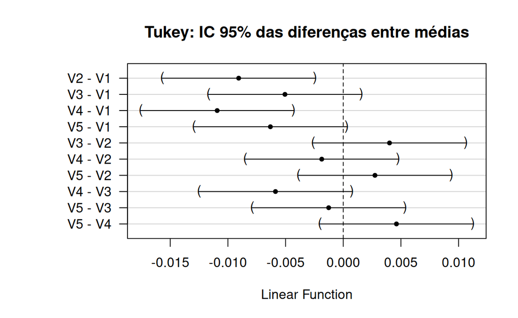

```r
mc_CI <- confint(mc, level = 0.95)

par(mar = c(5, 8, 4, 2))
plot(mc_CI, main = "Tukey: IC 95% das diferenças entre médias")
```

Os intervalos de confiança que não contêm o zero indicam diferença significativa. V2 e V4 têm retorno médio significativamente menor que V1 (p = 0,0020 e p = $9{,}96 \times 10^{-5}$). Juntando esse resultado ao boxplot, **V2 e V4 são descartadas**. Já V3 e V5 **não podem ser distinguidas de V1** ao nível de 5% (p = 0,2233 e p = 0,0698). Isso não prova que as médias são iguais, apenas que, com a correção para comparações múltiplas, os dados não trazem evidência de diferença. Note que entre V2, V3, V4 e V5 também não há diferença significativa entre si.

## Teste de Dunnett

Como V1 tem a maior média, ela é tomada como referência. Em vez de comparar todos os pares, o Dunnett compara apenas V1 contra cada uma das outras, o que dá mais sensibilidade para tentar descartar V3 e V5.

```r
retornos_long$acao <- relevel(retornos_long$acao, ref = "V1")
modelo2 <- aov(retorno ~ acao, data = retornos_long)

mc2 <- glht(modelo2, linfct = mcp(acao = "Dunnett"))
summary(mc2)
```

```
##
##   Simultaneous Tests for General Linear Hypotheses
##
## Multiple Comparisons of Means: Dunnett Contrasts
##
##
## Fit: aov(formula = retorno ~ acao, data = retornos_long)
##
## Linear Hypotheses:
##               Estimate Std. Error t value Pr(>|t|)
## V2 - V1 == 0 -0.009067   0.002403  -3.774   <0.001 ***
## V3 - V1 == 0 -0.005054   0.002403  -2.104   0.1176
## V4 - V1 == 0 -0.010931   0.002403  -4.549   <0.001 ***
## V5 - V1 == 0 -0.006316   0.002403  -2.629   0.0327 *
## ---
## Signif. codes:  0 '***' 0.001 '**' 0.01 '*' 0.05 '.' 0.1 ' ' 1
## (Adjusted p values reported -- single-step method)
```

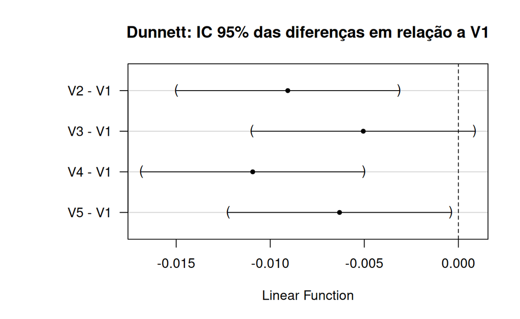

```r
mc2_CI <- confint(mc2, level = 0.95)

par(mar = c(5, 8, 4, 2))
plot(mc2_CI, main = "Dunnett: IC 95% das diferenças em relação a V1")
```

Com a sensibilidade extra, **V5 também é descartada** (p = 0,0326), além de V2 e V4 (p < 0,001 e < 0,001). Para V3, porém, o p-valor é 0,1176, e o intervalo de confiança da diferença (V3 − V1) contém o zero. Ainda não é possível afirmar que existe diferença entre V1 e V3, e as duas permanecem como candidatas.

## Teste t de Student

Restam duas candidatas, V1 e V3. Como é uma única comparação, não há necessidade de corrigir para comparações múltiplas, e o teste t entre as duas tem maior potência. As hipóteses são:

- $H_0$: as médias de retorno das ações V1 e V3 são iguais ($\mu_1 = \mu_3$);
- $H_1$: as médias de retorno das ações V1 e V3 são diferentes ($\mu_1 \neq \mu_3$).

```r
subset_v1_v3 <- subset(retornos_long, acao %in% c("V1", "V3"))
subset_v1_v3$acao <- droplevels(subset_v1_v3$acao)

teste_t <- t.test(retorno ~ acao, data = subset_v1_v3)   # Welch, bilateral
teste_t
```

```
##
##  Welch Two Sample t-test
##
## data:  retorno by acao
## t = 2.231, df = 67.876, p-value = 0.02899
## alternative hypothesis: true difference in means between group V1 and group V3 is not equal to 0
## 95 percent confidence interval:
##  0.0005334386 0.0095752061
## sample estimates:
## mean in group V1 mean in group V3
##      0.013403910      0.008349588
```

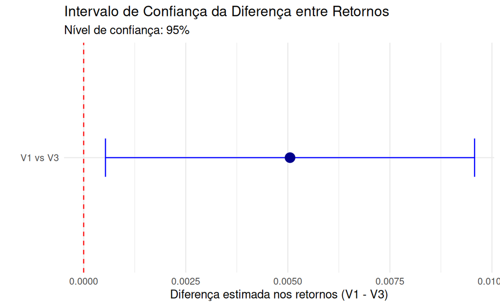

```r
library(ggplot2)
df_ic <- data.frame(
  Diferenca       = unname(teste_t$estimate[1] - teste_t$estimate[2]),  # V1 - V3
  Limite_Inferior = teste_t$conf.int[1],
  Limite_Superior = teste_t$conf.int[2],
  Comparacao      = "V1 vs V3"
)

ggplot(df_ic, aes(x = Comparacao, y = Diferenca)) +
  geom_hline(yintercept = 0, color = "red", linetype = "dashed") +
  geom_errorbar(aes(ymin = Limite_Inferior, ymax = Limite_Superior),
                width = 0.2, color = "blue") +
  geom_point(color = "darkblue", size = 4) +
  coord_flip() +
  labs(title = "Intervalo de Confiança da Diferença entre Retornos",
       subtitle = paste0("Nível de confiança: ",
                         attr(teste_t$conf.int, "conf.level") * 100, "%"),
       x = "", y = "Diferença estimada nos retornos (V1 - V3)") +
  theme_minimal()
```

## Risco e retorno (critério adicional de desempate)

Para reforçar a escolha entre V1 e V3, compara-se também o risco (desvio-padrão), a razão retorno/risco (sem taxa livre de risco) e o pior mês.

```r
risco <- data.frame(
  Media_pct = 100 * sapply(retornos, mean),
  DP_pct    = 100 * sapply(retornos, sd),
  Razao     = sapply(retornos, mean) / sapply(retornos, sd),
  Pior_mes  = 100 * sapply(retornos, min),
  Prop_meses_positivos = sapply(retornos, function(x) mean(x > 0))
)
knitr::kable(round(risco, 3),
             caption = "Retorno médio, risco e razão retorno/risco.")
```

Retorno médio, risco e razão retorno/risco.

|  | Media_pct | DP_pct | Razao | Pior_mes | Prop_meses_positivos |
| --- | --- | --- | --- | --- | --- |
| V1 | 1.340 | 0.927 | 1.445 | -0.266 | 0.914 |
| V2 | 0.434 | 0.864 | 0.502 | -2.240 | 0.714 |
| V3 | 0.835 | 0.968 | 0.863 | -0.812 | 0.829 |
| V4 | 0.247 | 1.179 | 0.210 | -1.574 | 0.543 |
| V5 | 0.709 | 1.058 | 0.670 | -2.899 | 0.829 |

A Tabela resume o desempenho de cada ação em termos de retorno e risco. As colunas são:

- **Media_pct:** retorno médio mensal, em porcentagem ($\bar{r}_j = \frac{1}{n}\sum_i r_{i,j}$). É o retorno que se espera, em média, ao investir na ação por um mês, e é a medida que os testes de hipóteses comparam.
- **DP_pct:** desvio-padrão dos retornos mensais, em porcentagem. Mede a variabilidade do retorno em torno da média e é usado aqui como medida de risco: quanto maior, mais incerto é o resultado do próximo mês.
- **Razao:** razão retorno/risco, calculada como média dividida pelo desvio-padrão ($\bar{r}_j / s_j$). Indica quanto retorno médio a ação entrega por unidade de risco assumido. É semelhante ao índice de Sharpe, mas sem descontar a taxa livre de risco. Não tem unidade, e quanto maior, melhor.
- **Pior_mes:** menor retorno mensal observado nos 35 meses, em porcentagem. Mostra a pior perda histórica em um único mês.
- **Prop_meses_positivos:** proporção de meses em que o retorno foi positivo (valor entre 0 e 1). Indica com que frequência a ação deu lucro no mês.

V1 combina a maior média (1,34%) com um dos menores riscos (desvio-padrão de 0,93%, menor que o de V3, 0,97%), e tem a maior razão retorno/risco (1,45 contra 0,86 de V3). Assim, V1 não apenas rende mais em média, como não exige assumir mais risco para isso.

# Conclusões e Recomendações

1. **Teste global:** o ANOVA rejeitou $H_0$ (p = $1{,}32 \times 10^{-4}$). As cinco ações não têm o mesmo retorno médio mensal.
2. **Ações que se destacam:** após as comparações múltiplas, V2 e V4 foram descartadas pelo teste de Tukey, e V5 foi descartada pelo teste de Dunnett. Restaram **V1 e V3**, sem diferença significativa entre si nos testes com correção para comparações múltiplas.
3. **Desempate:** o teste t entre V1 e V3 indicou V1 como superior (p = 0,0290). Os critérios adicionais favorecem V1: maior retorno médio, menor desvio-padrão e maior razão retorno/risco.
4. **Recomendação:** investir na ação **V1**, com retorno médio estimado de 1,34% ao mês. Se o investidor for averso a decisões baseadas em evidência marginal, V3 é a alternativa estatisticamente indistinguível, mas com retorno médio e razão retorno/risco menores. Vale lembrar que o retorno médio histórico não garante o retorno do próximo mês, pois a variabilidade mensal (cerca de 1 p.p.) é grande em relação às diferenças entre as médias.

# Discussão da significância e da potência dos testes

O nível de significância $\alpha = 0{,}05$ significa aceitar uma probabilidade de 5% de apontar diferença entre ações quando na realidade elas têm o mesmo retorno médio (erro tipo I). Nas comparações múltiplas (Tukey e Dunnett), esse nível se refere ao conjunto de comparações, e não a cada uma isoladamente, o que torna esses testes mais conservadores. O teste t final é uma comparação escolhida **depois** de ver os resultados anteriores e não foi corrigida, por isso o p-valor dele deve ser lido com cautela.

O risco oposto é o erro tipo II: não detectar uma diferença que existe. Esse risco é relevante entre V1 e V3, onde os testes não conseguem separar as ações com folga. A potência foi calculada para o contraste V1 contra V3, usando a diferença observada como tamanho de efeito (potência *a posteriori*, que serve apenas como referência):

```r
dif_v1v3 <- abs(mean(retornos$V1) - mean(retornos$V3))
sd_v1v3  <- sqrt((var(retornos$V1) + var(retornos$V3)) / 2)

power.t.test(n = n, delta = dif_v1v3, sd = sd_v1v3, sig.level = alpha)
```

```
##
##      Two-sample t test power calculation
##
##               n = 35
##           delta = 0.005054322
##              sd = 0.009477266
##       sig.level = 0.05
##           power = 0.5946211
##     alternative = two.sided
##
## NOTE: n is number in *each* group
```

```r
# n por ação necessário para 80% de potência nessa diferença
power.t.test(power = 0.8, delta = dif_v1v3, sd = sd_v1v3, sig.level = alpha)
```

```
##
##      Two-sample t test power calculation
##
##               n = 56.16893
##           delta = 0.005054322
##              sd = 0.009477266
##       sig.level = 0.05
##           power = 0.8
##     alternative = two.sided
##
## NOTE: n is number in *each* group
```

```r
# potência do teste global (ANOVA)
power.anova.test(groups = k, n = n,
                 between.var = var(colMeans(retornos)),
                 within.var  = mean(sapply(retornos, var)),
                 sig.level = alpha)
```

```
##
##      Balanced one-way analysis of variance power calculation
##
##          groups = 5
##               n = 35
##     between.var = 1.758459e-05
##      within.var = 0.0001010268
##       sig.level = 0.05
##           power = 0.9852461
##
## NOTE: n is number in each group
```

O teste global tem potência alta (0,99), o que é coerente com a rejeição clara de $H_0$. Para a comparação V1 contra V3, a potência é de apenas **59%** com 35 meses por ação. Seriam necessários cerca de **57 meses por ação** para ter 80% de potência para essa diferença. Em outras palavras, 36 meses de dados bastam para separar V1 de V2 e V4, mas não para separar V1 de V3 com segurança, e a incerteza que sobra nessa comparação vem desse limite de potência.

# Possíveis melhorias do experimento

- Ampliar a janela histórica (mais de 36 meses) e/ou usar retornos semanais, aumentando o número de observações e a potência.
- Considerar dividendos, custos de transação e impostos.
- Ajustar o retorno ao risco (índice de Sharpe, com taxa livre de risco) em vez de comparar só médias.
- Usar bootstrap ou testes de permutação para intervalos e comparações sem hipótese distribucional.
- Avaliar o desempenho fora da amostra (janela deslizante), já que rentabilidade passada não garante a do mês seguinte.
- Incluir mais ações e considerar diversificação (carteira) em vez de uma única ação.
- Definir antes do experimento a margem de equivalência economicamente relevante, para usar testes de equivalência/não inferioridade em vez de depender de $p$-valores marginais.

# Declaração sobre o uso de IA generativa

Durante a preparação deste trabalho, os autores utilizaram o Claude (Anthropic) para redigir a versão inicial das seções descritivas deste relatório, a partir dos resultados registrados como comentários no script de análise `exploracao_dos_dados.R`. Após utilizar essa ferramenta, os autores revisaram, editaram e finalizaram o conteúdo conforme necessário e assumem total responsabilidade pelo conteúdo da publicação.

Também foi utilizada IA para auxiliar na formatação do texto, incluindo a inclusão de bibliotecas que ajudam na visualização de gráficos e tabelas apresentados no relatório. Da mesma forma, foi solicitado apoio para revisar o chunk de setup do R Markdown, de modo a garantir a instalação das bibliotecas necessárias para que o arquivo compilasse sem erros.

# Referências

- MONTGOMERY, D. C. *Design and Analysis of Experiments*. John Wiley & Sons.
- TUKEY, J. W. Comparing individual means in the analysis of variance. *Biometrics*, v. 5, n. 2, p. 99–114, 1949.
- DUNNETT, C. W. A multiple comparison procedure for comparing several treatments with a control. *Journal of the American Statistical Association*, v. 50, n. 272, p. 1096–1121, 1955.
- R CORE TEAM. *R: A language and environment for statistical computing*. R Foundation for Statistical Computing, Vienna, Austria.
- Material da disciplina EEE933 (slides sobre ANOVA e comparações múltiplas), PPGEE/UFMG.